# Network Science of the Mid-Atlantic Region

Multilayer network science study of the Mid-Atlantic region logistics.

Network

Data Viz

Published

May 24, 2023

## About

This project is a multi-layer network science study on the Mid-Atlantic region. It is a student research project for [the FEW’s Lab](https://blogs.gwu.edu/caitlin-grady/) managed by Prof Caitlin Grady.

[Access the Project](https://pingfanhu.craft.me/few)

## Project Scope

The Mid-Atlantic Region

| No. | Abbr. | Full Name |
| --- | --- | --- |
| 1 | DC | District of Columbia |
| 2 | DE | Delaware |
| 3 | MD | Maryland |
| 4 | NC | North Carolina |
| 5 | NJ | New Jersey |
| 6 | NY | New York |
| 7 | PA | Pennsylvania |
| 8 | VA | Virginia |

The Multilayers

| No. | Layer |
| --- | --- |
| 1 | Airline |
| 2 | Marine |
| 3 | Rail |
| 4 | Road |

The latter part of this project focuses on layers of rail and road.

The codes can be modified so that you can expand to other selections of states, or to introduce other sources of `shp` files or `csv` files.

## Project Overview

### 1. Spatial Analysis

This section is the starting part of this project. It takes in geographical files from trusted sources and generates the proper maps and csv files out of them.

This section takes in `shp` files and `csv` files from these sources:

[TIGER/Line](https://www.census.gov/geographies/mapping-files/time-series/geo/tiger-line-file.2022.html#list-tab-790442341) [HIFLD](https://hifld-geoplatform.opendata.arcgis.com) [OurAirports](https://ourairports.com/data/)

This section generates:

- 9 `csv` files:
  - FAF zone correspondence
  - edges of airlines, marine, rails, and roads
  - nodes of airports, marine, rails and roads
- 2 maps - the spatial map and the topography map

The Spatial Map:

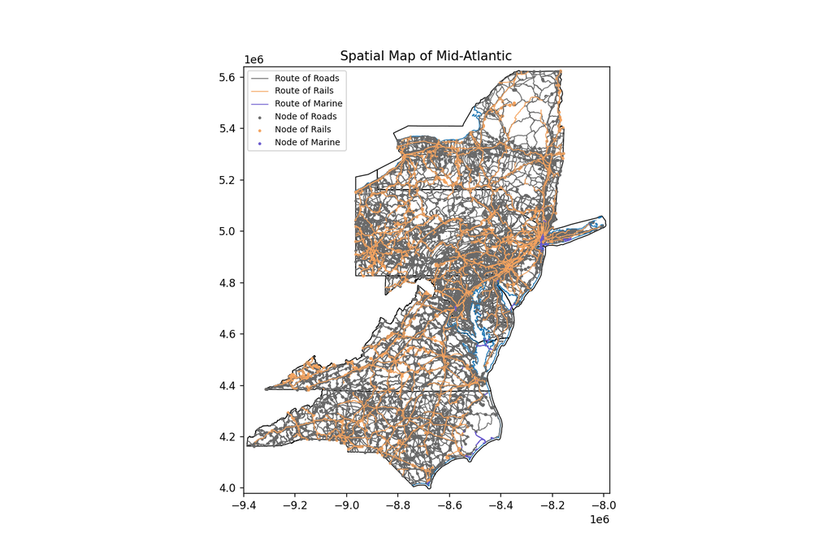

The Topography Map:

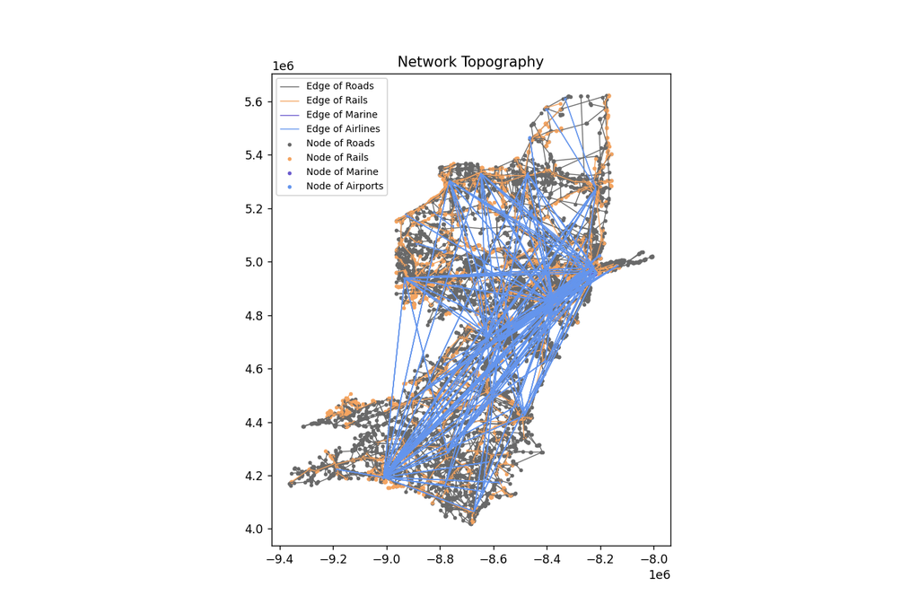

### 2. Centrality Analysis

This section takes in the 4 edge files and the 4 node files, and generates the 3 types of centralities of each.

The 3 types of centralities are: **betweenness** centrality, **closeness** centrality, and **degree** centrality.

Note that the centralities are all in **relative** values, which means their values are based on the size of the system network.

The centrality values are all listed in a *descending order*.

*Hint: any centrality `csv` file can also be used as a collection of nodes in its corresponding layer.*

### 3. Path Calculation

Starting from this section, we only focus on the **rail** and **road** layers.

This section takes in edge and node files of rail and roads, and generates path counts.

The path counts are based on *FAF zones* of all 8 states, so that each OD pair is inter-FAF-zone.

There are **40** rail OD pairs, and **186** road OD pairs.

The `csv` headers are:

1. No. - counting number starting from 1
2. Source - the source node
3. Source State
4. Source FAF Zone
5. Source FAF Zone Description
6. Target - the target node
7. Target State
8. Target FAF Zone
9. Target FAF Zone Description
10. Path Count - the count of shortest paths

### 4. Degree Centrality Dist

This section takes in the degree centralities of rails and roads, and generates the degree centrality distribution plots of them.

The *Rail* Degree Centrality Distribution plot:

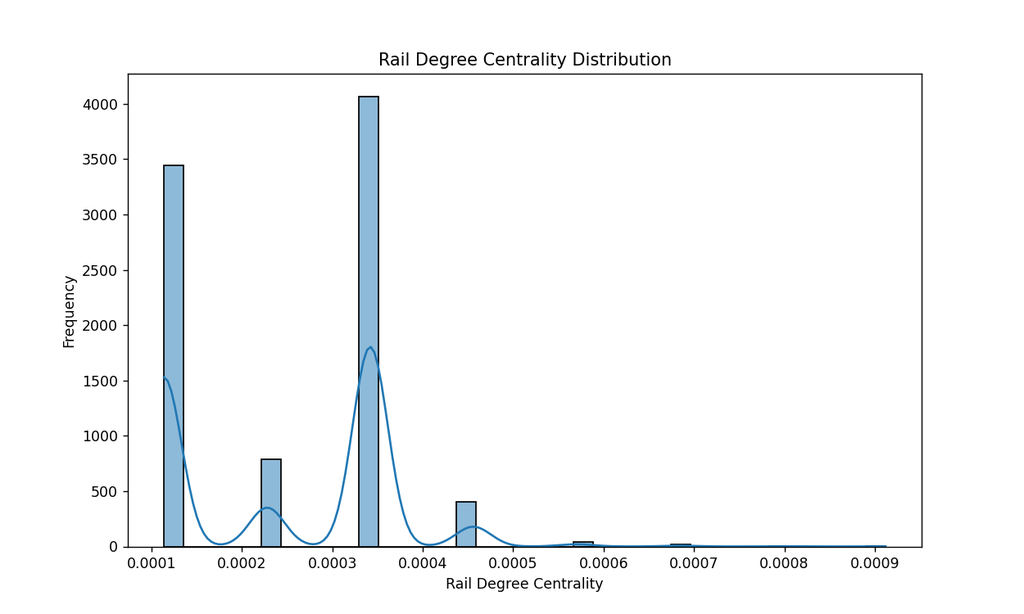

The *Road* Degree Centrality Distribution plot:

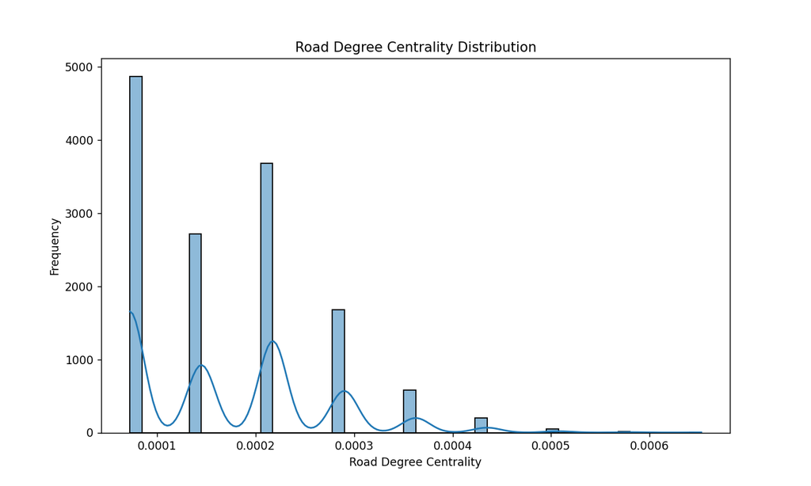

### 5. Network Attacks

This section generates the deterministic and stochastic attacks on rails and roads.

It takes in these files:

- edge and node `csv` files
- path count files
- 3 ranked centrality files (betweenness centrality also used as node collections)

The plots contain:

- Deterministic removal plots of the 3 centralities
- Stochastic removal with random node selections (surrounded by 95% CI)

The Rail Centrality Attack plot:

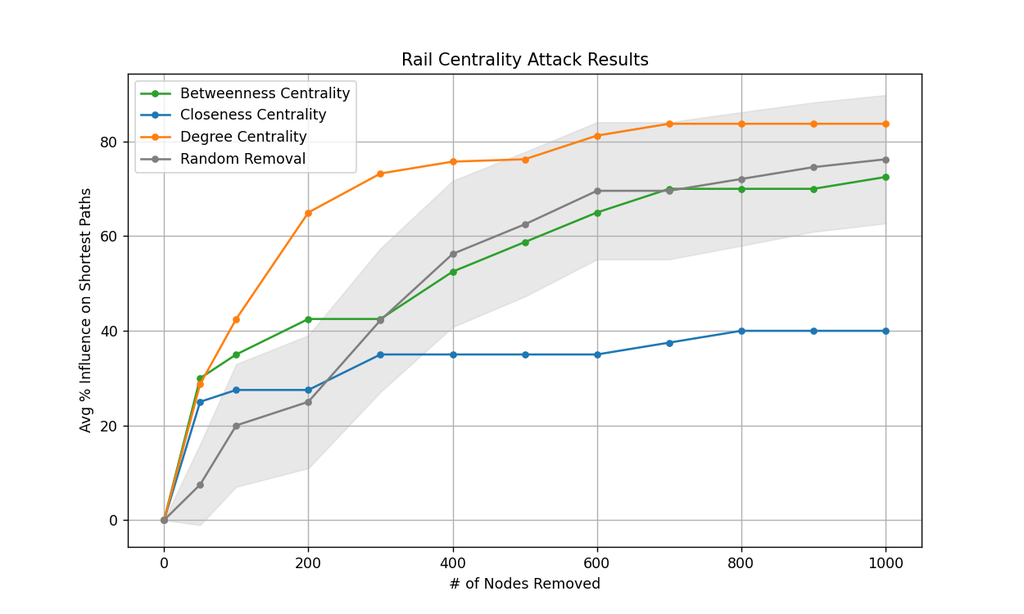

The Road Centrality Attack plot:

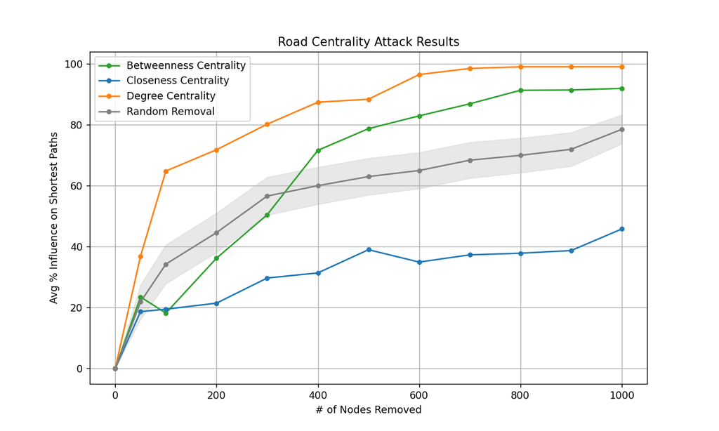

Back to top